# Development and Q&A

Gerko Vink

g.vink@uu.nl

Methodology & Statistics @ Utrecht University

13 Jun 2025

## Disclaimer

I owe a debt of gratitude to many people as the thoughts and code in these slides are the process of years-long development cycles and discussions with my team, friends, colleagues and peers. When someone has contributed to the content of the slides, I have credited their authorship.

Images are either directly linked, or generated with StableDiffusion or DALL-E. That said, there is no information in this presentation that exceeds legal use of copyright materials in academic settings, or that should not be part of the public domain.

**Warning**

You **may use** any and all content in this presentation - including my name - and submit it as input to generative AI tools, with the following **exception**:

- You must ensure that the content is not used for further training of the model

## Slide materials and source code

**Materials**

- lecture slides on Moodle
- course page: www.gerkovink.com/sur
- source: github.com/gerkovink/sur

## Recap

Gisteren hebben we deze onderwerpen behandeld:

- Basisplots: histogrammen, scatterplots en boxplots
- Geavanceerde plots met ggplot2
- Aanpassen van grafieken voor publicatie
- Exporteren van grafieken en resultaten

## Today

Vandaag behandelen we de volgende onderwerpen:

- Zelf R-packages maken
- Samenvatting + Q&A

# Samenvatting (met stiekem wat nieuws)

## Simpele data containers

```r
c(1, 2, 3, 4, 5) # een vector met waarden 1 tot en met 5
```

```
[1] 1 2 3 4 5
```

```r
1:10 # een vector met waarden 1 tot en met 10
```

```
 [1]  1  2  3  4  5  6  7  8  9 10
```

```r
letters[1:10] # de eerste 10 elementen uit het letters object
```

```
 [1] "a" "b" "c" "d" "e" "f" "g" "h" "i" "j"
```

```r
a <- c(1, 2, 3, 4, 5) # een vector assigned naar a
a[3] # element 3 uit a
```

```
[1] 3
```

```r
a[1:3] # element 1, 2 en 3 uit a
```

```
[1] 1 2 3
```

```r
a[5:3] # element 5, 4 en 3 uit a
```

```
[1] 5 4 3
```

```r
c(a, "oeps") # alles is nu character
```

```
[1] "1"    "2"    "3"    "4"    "5"    "oeps"
```

## Matrices en data frames

```r
m <- matrix(1:9, nrow = 3) # een matrix met 3 rijen en 3 kolommen
m
```

```
     [,1] [,2] [,3]
[1,]    1    4    7
[2,]    2    5    8
[3,]    3    6    9
```

```r
m[2, 3] # element in rij 2, kolom 3
```

```
[1] 8
```

```r
m[1:2, 2:3] # elementen in rij 1 en 2, kolom 2 en 3
```

```
     [,1] [,2]
[1,]    4    7
[2,]    5    8
```

```r
df <- data.frame(a = 1:3, b = letters[1:3]) # data frame met 3 rijen, 2 kolommen
df[, 2] # tweede kolom van df
```

```
[1] "a" "b" "c"
```

```r
df$b # tweede kolom van df, met de naam b --> vandaar dat we $ kunnen gebruiken
```

```
[1] "a" "b" "c"
```

## Datasets inlezen

```r
library(haven) # voor het inlezen van SPSS, Stata en SAS bestanden
library(magrittr) # voor pipes
library(dplyr) # voor data manipulatie
# inlezen van een Stata bestand
stata <- read_dta("files/03-poverty-analysis-data-2022-rt001-housing-plus.dta")
stata %>% glimpse()
```

```
Rows: 2,502
Columns: 114
$ hhid          <dbl> 1102500401, 1102500501, 1102500502, 1102501202, 11074305…
$ domain2       <dbl+lbl> 1.1, 1.1, 1.1, 1.1, 1.1, 1.1, 1.1, 1.1, 1.1, 2.0, 2.…
$ psu           <dbl> 10250, 10250, 10250, 10250, 10743, 10743, 10743, 10743, …
$ domain        <dbl+lbl> 1, 1, 1, 1, 1, 1, 1, 1, 1, 2, 2, 2, 2, 2, 2, 2, 2, 2…
$ gp_subdom     <dbl+lbl> 1, 1, 1, 1, 1, 1, 1, 1, 1, 0, 0, 0, 0, 0, 0, 0, 0, 0…
$ district      <chr> "Paramaribo", "Paramaribo", "Paramaribo", "Paramaribo", …
$ fortnight     <dbl> 1, 1, 1, 1, 1, 1, 1, 1, 1, 1, 1, 1, 1, 1, 1, 1, 1, 1, 1,…
$ panel         <dbl+lbl> 1, 1, 1, 1, 1, 1, 1, 1, 1, 1, 1, 1, 1, 1, 1, 1, 1, 1…
$ hhid16        <dbl> 6015041, 6015051, 6015052, 6015122, 6039051, 6039081, 60…
$ lat_cen       <dbl> 5.847621, 5.847621, 5.847621, 5.847621, 5.819147, 5.8191…
$ long_cen      <dbl> -55.17032, -55.17032, -55.17032, -55.17032, -55.21745, -…
$ result        <dbl+lbl> 1, 1, 1, 1, 1, 1, 1, 1, 1, 1, 1, 1, 1, 1, 1, 1, 1, 1…
$ end_date_n    <date> 2022-01-04, 2022-01-05, 2022-01-10, 2022-01-04, 2022-01…
```

[output cut: 101 more lines]

## Datasets inspecteren

```r
stata %>% head(n = 5) # eerste 5 rijen van de dataset
```

```
# A tibble: 5 × 114
        hhid domain2     psu domain  gp_subdom district fortnight panel   hhid16
       <dbl> <dbl+lbl> <dbl> <dbl+l> <dbl+lbl> <chr>        <dbl> <dbl+l>  <dbl>
1 1102500401 1.1       10250 1 [Gre… 1 [Param… Paramar…         1 1 [Pan… 6.02e6
2 1102500501 1.1       10250 1 [Gre… 1 [Param… Paramar…         1 1 [Pan… 6.02e6
3 1102500502 1.1       10250 1 [Gre… 1 [Param… Paramar…         1 1 [Pan… 6.02e6
4 1102501202 1.1       10250 1 [Gre… 1 [Param… Paramar…         1 1 [Pan… 6.02e6
5 1107430501 1.1       10743 1 [Gre… 1 [Param… Paramar…         1 1 [Pan… 6.04e6
# ℹ 105 more variables: lat_cen <dbl>, long_cen <dbl>, result <dbl+lbl>,
#   end_date_n <date>, Year_s <dbl>, Month_s <dbl>, Day <dbl>, stratum <dbl>,
#   hhid_text <chr>, HHsize <dbl>, HHsize2 <dbl>, interv <dbl>, end_date <chr>,
#   q17_02 <dbl+lbl>, q17_03a <dbl+lbl>, q17_03b <dbl+lbl>, q17_04 <dbl+lbl>,
#   q12a <dbl+lbl>, q12_01a <dbl>, q12_01b <dbl>, q12_02a <dbl>, q12_02b <dbl>,
#   q12_03a <dbl>, q12_03b <dbl>, q12_04a <dbl>, q12_04b <dbl>,
#   q12_05 <dbl+lbl>, q13_01 <dbl+lbl>, q13_01_ot <chr>, q13_02 <dbl+lbl>, …
```

```r
stata %>% slice_head(n = 2) # eerste 2 rijen van de dataset
```

```
# A tibble: 2 × 114
        hhid domain2     psu domain  gp_subdom district fortnight panel   hhid16
       <dbl> <dbl+lbl> <dbl> <dbl+l> <dbl+lbl> <chr>        <dbl> <dbl+l>  <dbl>
1 1102500401 1.1       10250 1 [Gre… 1 [Param… Paramar…         1 1 [Pan… 6.02e6
2 1102500501 1.1       10250 1 [Gre… 1 [Param… Paramar…         1 1 [Pan… 6.02e6
# ℹ 105 more variables: lat_cen <dbl>, long_cen <dbl>, result <dbl+lbl>,
#   end_date_n <date>, Year_s <dbl>, Month_s <dbl>, Day <dbl>, stratum <dbl>,
#   hhid_text <chr>, HHsize <dbl>, HHsize2 <dbl>, interv <dbl>, end_date <chr>,
#   q17_02 <dbl+lbl>, q17_03a <dbl+lbl>, q17_03b <dbl+lbl>, q17_04 <dbl+lbl>,
#   q12a <dbl+lbl>, q12_01a <dbl>, q12_01b <dbl>, q12_02a <dbl>, q12_02b <dbl>,
#   q12_03a <dbl>, q12_03b <dbl>, q12_04a <dbl>, q12_04b <dbl>,
#   q12_05 <dbl+lbl>, q13_01 <dbl+lbl>, q13_01_ot <chr>, q13_02 <dbl+lbl>, …
```

## Datasets corrigeren

```r
stata %>%
  as_factor() %>% # alle labelled variabelen omzetten naar factor
  glimpse()
```

```
Rows: 2,502
Columns: 114
$ hhid          <dbl> 1102500401, 1102500501, 1102500502, 1102501202, 11074305…
$ domain2       <fct> 1.1, 1.1, 1.1, 1.1, 1.1, 1.1, 1.1, 1.1, 1.1, Rest of the…
$ psu           <dbl> 10250, 10250, 10250, 10250, 10743, 10743, 10743, 10743, …
$ domain        <fct> Great Paramaribo, Great Paramaribo, Great Paramaribo, Gr…
$ gp_subdom     <fct> Paramaribo, Paramaribo, Paramaribo, Paramaribo, Paramari…
$ district      <chr> "Paramaribo", "Paramaribo", "Paramaribo", "Paramaribo", …
$ fortnight     <dbl> 1, 1, 1, 1, 1, 1, 1, 1, 1, 1, 1, 1, 1, 1, 1, 1, 1, 1, 1,…
$ panel         <fct> Panel, Panel, Panel, Panel, Panel, Panel, Panel, Panel, …
$ hhid16        <dbl> 6015041, 6015051, 6015052, 6015122, 6039051, 6039081, 60…
$ lat_cen       <dbl> 5.847621, 5.847621, 5.847621, 5.847621, 5.819147, 5.8191…
$ long_cen      <dbl> -55.17032, -55.17032, -55.17032, -55.17032, -55.21745, -…
$ result        <fct> Interview finalized - Fully completed, Interview finaliz…
$ end_date_n    <date> 2022-01-04, 2022-01-05, 2022-01-10, 2022-01-04, 2022-01…
```

[output cut: 101 more lines]

Let op dat deze dan wel goed gelabelled zijn!

## Tabellen en kruistabellen

```r
stata %$% # exposition pipe
  table(HHsize) # frequentietabel van HHsize
```

```
HHsize
  1   2   3   4   5   6   7   8   9  10  11  12  16
563 617 445 407 252 103  45  34  17  13   1   3   2
```

```r
stata %$% # exposition pipe
  table(HHsize, district) # kruistabel van HHsize en district
```

```
      district
HHsize Brokopondo Commewijne Coronie Marowijne Nickerie Para Paramaribo
    1           1         38      10        18       38   11        219
    2           2         46       6        16       55    4        235
    3           1         31       2        13       48    3        169
    4           2         23       8         7       37    3        169
    5           0         20       3         4       20    2         92
    6           0          5       3         7        7    0         32
    7           0          2       1         8        5    0         10
    8           1          2       0         1        1    2          9
    9           0          2       0         0        1    1          5
    10          0          1       0         1        1    0          4
    11          0          0       0         0        0    0          0
    12          0          0       0         0        0    1          0
    16          0          0       0         0        0    0          1
      district
HHsize Saramacca Sipaliwini Wanica
    1         51         54    123
    2         70         28    155
    3         38         14    126
    4         38          9    111
    5         23          3     85
    6          3          5     41
    7          4          1     14
    8          4          1     13
    9          2          0      6
    10         0          1      5
    11         0          0      1
    12         0          2      0
    16         0          0      1
```

## Datasets manipuleren: filter OF select

```r
stata %>%
  filter(district == "Commewijne" | district == "Nickerie") %$% # filter op district
  table(district)
```

```
district
Commewijne   Nickerie
       170        213
```

```r
stata %>%
  select(district, HHsize) %>% # selecteer kolommen
  head()
```

```
# A tibble: 6 × 2
  district   HHsize
  <chr>       <dbl>
1 Paramaribo      1
2 Paramaribo      3
3 Paramaribo      1
4 Paramaribo      4
5 Paramaribo      1
6 Paramaribo      2
```

## Datasets manipuleren: filter EN select

```r
stata %>%
  filter(district == "Commewijne" | district == "Nickerie") %>% # filter op district
  select(district, HHsize) %>% # selecteer kolommen
  head()
```

```
# A tibble: 6 × 2
  district   HHsize
  <chr>       <dbl>
1 Commewijne      2
2 Commewijne      2
3 Commewijne      2
4 Commewijne      2
5 Commewijne      1
6 Commewijne      5
```

## Datasets manipuleren: mutate

```r
stata %<>% # assign pipe ipv `stata <- stata %>%`
  as_factor() %>% # alle labelled variabelen omzetten naar factor
  mutate(HHclass = ifelse(test = HHsize > 5, # Als HHsize groter dan 5
                          yes = "groot", # dan is HHclass groot
                          no = "niet groot")) # anders is HHclass niet groot

stata %<>%
  mutate(HHclass2 = case_when(HHsize > 5 ~ "groot",
                             HHsize <= 5 ~ "niet groot"))
```

## Datasets manipuleren: group_by en summarise

```r
stata %>%
  group_by(district) %>% # groepeer op district
  summarise(mean_HHsize = mean(HHsize, na.rm = TRUE), # gemiddelde HHsize per district
            median_HHsize = median(HHsize, na.rm = TRUE), # mediaan HHsize per district)
            sd_HHsize = sd(HHsize, na.rm = TRUE), # standaarddeviatie HHsize perm district
            IQR_HHsize = IQR(HHsize, na.rm = TRUE)) # interkwartielafstand HHsize per district
```

```
# A tibble: 10 × 5
   district   mean_HHsize median_HHsize sd_HHsize IQR_HHsize
   <chr>            <dbl>         <dbl>     <dbl>      <dbl>
 1 Brokopondo        3.43             3      2.30          2
 2 Commewijne        2.96             3      1.80          2
 3 Coronie           3.03             3      1.85          3
 4 Marowijne         3.37             3      2.22          3
 5 Nickerie          3.02             3      1.65          2
 6 Para              3.22             2      2.94          3
 7 Paramaribo        2.93             3      1.74          2
 8 Saramacca         2.87             2      1.69          2
 9 Sipaliwini        2.39             2      2.10          2
10 Wanica            3.32             3      1.97          2
```

## T-toets

```r
# var.test
stata %>%
  filter(district == "Paramaribo" | district == "Wanica") %$% # filter op district
  var.test(HHsize ~ district) # t-toets voor gelijke varianties
```

```
    F test to compare two variances

data:  HHsize by district
F = 0.78023, num df = 944, denom df = 680, p-value = 0.0004469
alternative hypothesis: true ratio of variances is not equal to 1
95 percent confidence interval:
 0.6780808 0.8963271
sample estimates:
ratio of variances
         0.7802292
```

```r
stata %>%
  filter(district == "Paramaribo" | district == "Wanica") %$% # filter op district
  t.test(HHsize ~ district, var.equal = FALSE) # t-toets voor gelijke varianties
```

```
    Welch Two Sample t-test

data:  HHsize by district
t = -4.1222, df = 1351.8, p-value = 3.981e-05
alternative hypothesis: true difference in means between group Paramaribo and group Wanica is not equal to 0
95 percent confidence interval:
 -0.5743252 -0.2039514
sample estimates:
mean in group Paramaribo     mean in group Wanica
                2.928042                 3.317181
```

## $\chi^2$-toets

```r
stata %>%
  filter(district == "Paramaribo" | district == "Wanica") %$% # filter op district
  table(HHclass, district)
```

```
            district
HHclass      Paramaribo Wanica
  groot              61     81
  niet groot        884    600
```

```r
stata %>%
  filter(district == "Paramaribo" | district == "Wanica") %$% # filter op district
  table(HHclass, district) %>%
  chisq.test() # chi-kwadraattoets voor kruistabel van HHclass en district
```

```
    Pearson's Chi-squared test with Yates' continuity correction

data:  .
X-squared = 14.017, df = 1, p-value = 0.0001812
```

## Expected and observed frequencies

```r
X2 <- stata %>%
  filter(district == "Paramaribo" | district == "Wanica") %$% # filter op district
  table(HHclass, district) %>%
  chisq.test() # chi-kwadraattoets voor kruistabel van HHclass en district
X2$observed # waargenomen frequenties
```

```
            district
HHclass      Paramaribo Wanica
  groot              61     81
  niet groot        884    600
```

```r
X2$expected # verwachte frequenties
```

```
            district
HHclass      Paramaribo    Wanica
  groot        82.52768  59.47232
  niet groot  862.47232 621.52768
```

```r
stata %>%
  filter(district == "Paramaribo" | district == "Wanica") %$% # filter op district
  table(HHclass, district) %>%
  fisher.test()
```

```
    Fisher's Exact Test for Count Data

data:  .
p-value = 0.000169
alternative hypothesis: true odds ratio is not equal to 1
95 percent confidence interval:
 0.3546500 0.7342262
sample estimates:
odds ratio
  0.511352
```

## Missende waarden

```r
library(mice)
library(ggmice)
imp <- mice(mice::nhanes2, print = FALSE)
imp$data %>%
  plot_pattern()
```

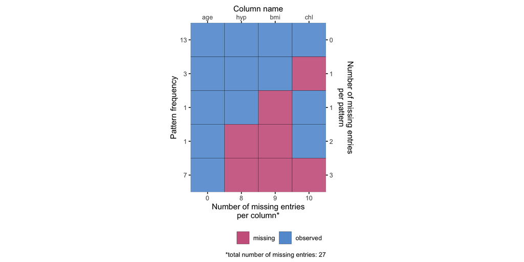

## Analyzing imputations

```r
library(purrr)
imp %>%
  complete("all") %>% # list met alle geimputeerde data sets
  map(~.x %$% mean(bmi))
```

```
$`1`
[1] 27.448

$`2`
[1] 26.492

$`3`
[1] 26.364

$`4`
[1] 26.82

$`5`
[1] 27.388
```

```r
imp %>%
  complete("all") %>% # list met alle geimputeerde data sets
  map_df(~.x %$% mean(bmi))
```

```
# A tibble: 1 × 5
    `1`   `2`   `3`   `4`   `5`
  <dbl> <dbl> <dbl> <dbl> <dbl>
1  27.4  26.5  26.4  26.8  27.4
```

## Analyzing imputations: averaging

```r
library(purrr)
imp %>%
  complete("all") %>% # list met alle geimputeerde data sets
  map(~.x %$% mean(bmi)) %>%
  reduce(`+`) / imp$m
```

```
[1] 26.9024
```

```r
imp %>%
  complete("all") %>% # list met alle geimputeerde data sets
  map_df(~.x %$% mean(bmi)) %>%
  rowMeans()
```

```
[1] 26.9024
```

## Analyzing imputations: pooling

```r
imp %>%
  complete("all") %>% # list met alle geimputeerde data sets
  map(~.x %$% lm(bmi ~ chl)) %>%
  pool() %>%  # pooling van de resultaten
  summary() # samenvatting van de resultaten
```

```
         term    estimate  std.error statistic       df      p.value
1 (Intercept) 21.14641280 4.45946158  4.741921 16.60657 0.0002005259
2         chl  0.02958428 0.02237211  1.322374 16.71592 0.2038528932
```

## Plotting

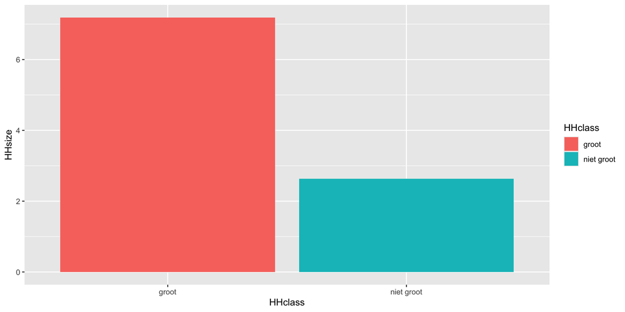

```r
library(ggplot2)
stata %>%
  ggplot(aes(x = HHclass, y = HHsize, fill = HHclass)) + # plot HHsize per district
  geom_bar(stat = "summary", fun = "mean") # staafdiagram met gemiddelde HHsize per district
```

## Plotting: histogram

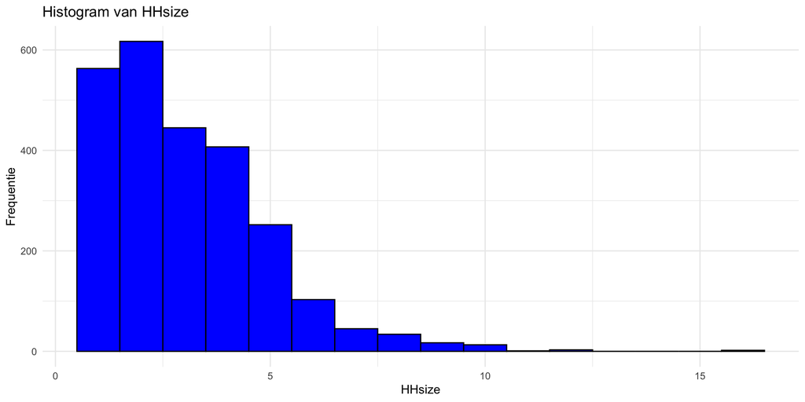

```r
stata %>%
  ggplot(aes(x = HHsize)) + # plot HHsize
  geom_histogram(binwidth = 1, fill = "blue", color = "black") + # histogram met binwidth van 1
  labs(title = "Histogram van HHsize", x = "HHsize", y = "Frequentie") + # titel en labels
  theme_minimal() # minimalistisch thema
```

# Development

## `Browser()`

```r
myfunction <- function(x) {
  # Deze functie doet iets met x
  x_squared <- x^2 # kwadrateert x
  browser() # zet een breakpoint in de code
  return(x_squared) # geeft het kwadraat van x terug
}
```

## `reprex()`

Demo

# Live R-package maken

[figure not shown]

Gerko Vink @ Anton de Kom Universiteit, Paramaribo